# PUBHBIO 6211: Practice Exercises Block 7

# Exercise 1

We have a sample of 200 people, with age (in years) and bond mineral density (**bmd**) for each person. A simple linear regression model was run using age to predict BMD. Output is below.

```stata
. regress bmd age

      Source |       SS           df       MS      Number of obs   =       200
-------------+----------------------------------   F(1, 198)       =     54.86
       Model |  1.62569273         1  1.62569273   Prob > F        =    0.0000
    Residual |  5.86753243       198  .029634002   R-squared       =    0.2170
-------------+----------------------------------   Adj R-squared   =    0.2130
       Total |  7.49322516       199  .037654398   Root MSE        =    .17215

------------------------------------------------------------------------------
         bmd |      Coef.   Std. Err.      t    P>|t|     [95% Conf. Interval]
-------------+----------------------------------------------------------------
         age |  -.0046087   .0006222    -7.41   0.000    -.0058358   -.0033817
       _cons |   1.164711   .0332406    35.04   0.000      1.09916    1.230262
------------------------------------------------------------------------------
```

1. Interpret the effect of age on BMD based on this model. Is there evidence of a significant effect?
2. Report and interpret the R$^2$ value for this model.
3. In checking the model assumptions, one useful plot is a Q-Q plot of the residuals. This plot is below. Do there appear to be any outliers based on this plot?

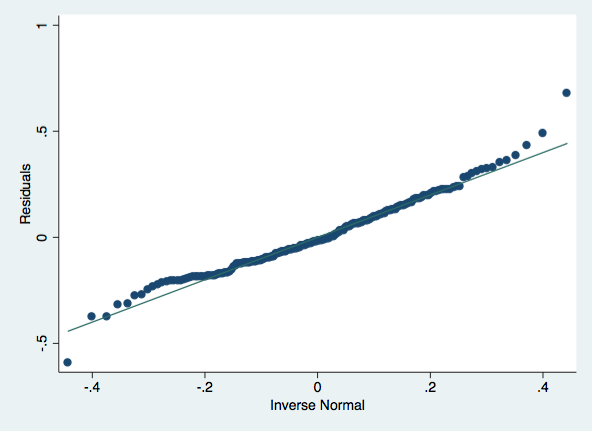

Q-Q Plot

4. As a next step, the studentized residuals were calculated. Using the output below, identify what (if any) IDs you are most concerned about as potential outliers.

```stata
. list id rhat if rhat > 2 | rhat < -2

     +-----------------+
     |  id        rhat |
     |-----------------|
  3. |   3    2.257787 |
 12. |  12    2.549181 |
 31. |  31     2.12993 |
 40. |  40   -2.206589 |
130. | 130   -3.566072 |
     |-----------------|
150. | 150    2.059209 |
151. | 151    4.165857 |
164. | 164      2.8946 |
185. | 185   -2.233705 |
     +-----------------+
```

5. Next, a leverage-versus-squared-residuals plot was generated. Two versions of the plot are shown below – one with and one without the IDs superimposed. Are there any points that you think might be highly influential based on this plot? If so, report the ID(s) and explain why they might be highly influential.

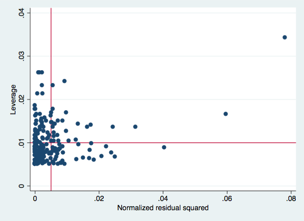

Plot without ID labels

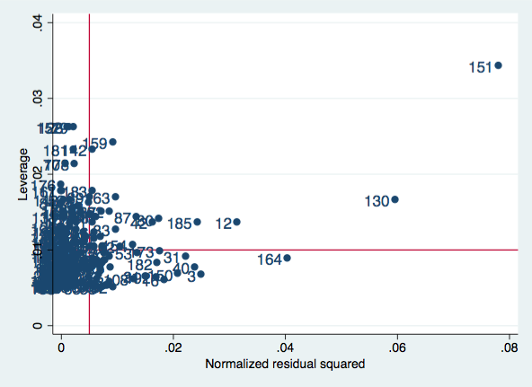

Plot with ID labels

6. The DFBETAs for the model were calculated and plotted as shown below (once with and once without the IDs superimposed). Do the DFBETAs support your conclusion in part (e)?

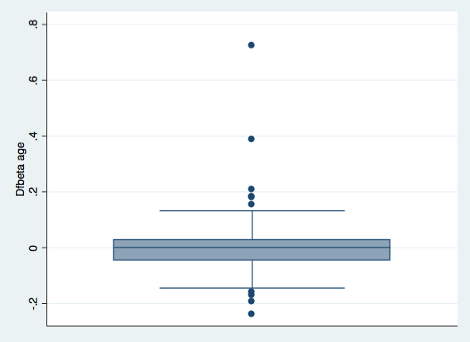

Plot without ID labels

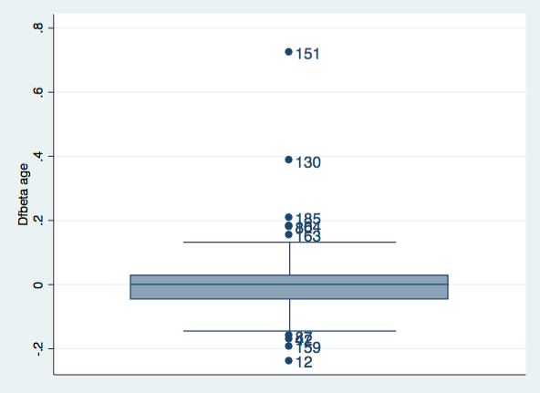

Plot with ID labels

The regression model was run with again, removing the one influential point. Output is below.

```stata
. regress bmd age if id ~= 151

      Source |       SS           df       MS      Number of obs   =       199
-------------+----------------------------------   F(1, 197)       =     69.00
       Model |  1.88863492         1  1.88863492   Prob > F        =    0.0000
    Residual |  5.39249059       197  .027373049   R-squared       =    0.2594
-------------+----------------------------------   Adj R-squared   =    0.2556
       Total |  7.28112551       198  .036773361   Root MSE        =    .16545

------------------------------------------------------------------------------
         bmd |      Coef.   Std. Err.      t    P>|t|     [95% Conf. Interval]
-------------+----------------------------------------------------------------
         age |  -.0050421    .000607    -8.31   0.000    -.0062392    -.003845
       _cons |   1.182745   .0322393    36.69   0.000     1.119167    1.246324
------------------------------------------------------------------------------
```

7. Interpret the effect of age on BMD based on this model with the influential point removed. Is there evidence of a significant effect? How do these results compare to the original results?
8. Report and interpret the R$^2$ value for this model. Compare this to the R$^2$ from the original results.

# Exercise 2

We have measured the IL-6, an inflammatory cytokine in the blood (units: pg/ml), in a sample of 85 adults. We also know the age (years) and sex (1=male, 0=female) of each person. We are interested whether higher IL-6 is associated with depression, with depression measured using a scale where higher means worse depression. Initially, we fit the model as shown below in Stata.

```stata
. regress depress il6 age

      Source |       SS           df       MS      Number of obs   =        85
-------------+----------------------------------   F(2, 82)        =     10.57
       Model |  94.9158104         2  47.4579052   Prob > F        =    0.0001
    Residual |  368.331248        82  4.49184449   R-squared       =    0.2049
-------------+----------------------------------   Adj R-squared   =    0.1855
       Total |  463.247059        84  5.51484594   Root MSE        =    2.1194

------------------------------------------------------------------------------
     depress |      Coef.   Std. Err.      t    P>|t|     [95% Conf. Interval]
-------------+----------------------------------------------------------------
         il6 |   .0883511   .0196082     4.51   0.000     .0493442    .1273579
         age |   .0537898   .0556169     0.97   0.336      -.05685    .1644296
       _cons |   2.470479   2.803275     0.88   0.381    -3.106127    8.047085
------------------------------------------------------------------------------
```

1. Interpret the effect of IL-6 in this model. Is there evidence of a significant effect? (assume $\alpha$=0.05)
2. Interpret the effect of age in this model. Is there evidence of a significant effect? (assume $\alpha$=0.05)
3. What is the $R^2$ for this model? Interpret this quantity.

Based on the CPR plot below, it appears that there may be a non-linear effect of IL-6, and a log-transformation may be appropriate. Thus, The model was run using natural log-transformed IL-6. Stata output is below the figure.

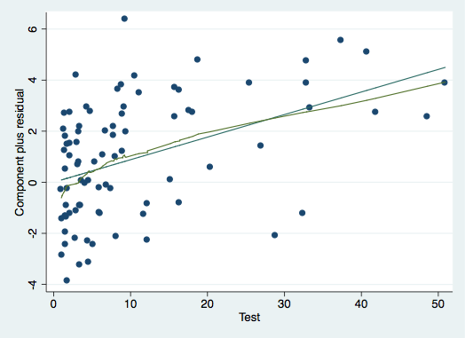

CPR Plot

```stata
. generate ln_il6 = ln(il6)
. regress depress ln_il6 age

      Source |       SS           df       MS      Number of obs   =        85
-------------+----------------------------------   F(2, 82)        =     12.00
       Model |  104.872944         2  52.4364722   Prob > F        =    0.0000
    Residual |  358.374115        82  4.37041603   R-squared       =    0.2264
-------------+----------------------------------   Adj R-squared   =    0.2075
       Total |  463.247059        84  5.51484594   Root MSE        =    2.0906

------------------------------------------------------------------------------
     depress |      Coef.   Std. Err.      t    P>|t|     [95% Conf. Interval]
-------------+----------------------------------------------------------------
      ln_il6 |   1.034924   .2151201     4.81   0.000     .6069821    1.462867
         age |    .055592   .0548654     1.01   0.314    -.0535527    .1647368
       _cons |   1.440774   2.789832     0.52   0.607     -4.10909    6.990638
------------------------------------------------------------------------------
```

4. Interpret the effect of IL-6 in this model. Is there evidence of a significant effect? (assume $\alpha$=0.05)
5. How does depression score change if IL-6 increases by 10%?
6. Interpret the effect of age in this model. Is there evidence of a significant effect? (assume $\alpha$=0.05)
7. What is the $R^2$ for this model? Interpret this quantity, and compare to the $R^2$ in the original model.

# Exercise 3

In the same sample of 85 people, we have another cytokine measured, called TNF (units: pg/ml). We would like to know if age and sex are associated with TNF. A regression was run using age and sex to predict TNF. Output is below.

```stata
. regress tnf sex age

      Source |       SS           df       MS      Number of obs   =        85
-------------+----------------------------------   F(2, 82)        =      7.33
       Model |  7.48742689         2  3.74371345   Prob > F        =    0.0012
    Residual |  41.8874142        82  .510822124   R-squared       =    0.1516
-------------+----------------------------------   Adj R-squared   =    0.1310
       Total |  49.3748411        84  .587795727   Root MSE        =    .71472

------------------------------------------------------------------------------
         tnf |      Coef.   Std. Err.      t    P>|t|     [95% Conf. Interval]
-------------+----------------------------------------------------------------
         sex |   .5026441   .1559238     3.22   0.002      .192462    .8128262
         age |   .0383495   .0187544     2.04   0.044      .001041     .075658
       _cons |  -.5466748    .943964    -0.58   0.564     -2.42452     1.33117
------------------------------------------------------------------------------
```

1. Interpret the effect of age in this model. Is there evidence of a significant effect? (assume $\alpha$=0.05)
2. Interpret the effect of sex in this model. Is there evidence of a significant effect? (assume $\alpha$=0.05)
3. Based on the histogram of residuals from this model and the RVF plot (both shown below), do there appear to be any problems with model assumptions?

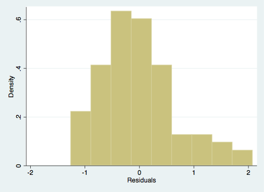

Histogram of Residuals

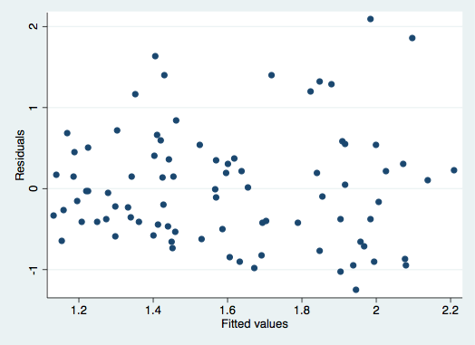

RVF Plot

The model was re-run, using natural log-transformed TNF as the outcome. Output is below.

```stata
. generate ln_tnf = ln(tnf)

. regress ln_tnf sex age

      Source |       SS           df       MS      Number of obs   =        85
-------------+----------------------------------   F(2, 82)        =      6.83
       Model |  2.58442832         2  1.29221416   Prob > F        =    0.0018
    Residual |  15.5232379        82  .189307779   R-squared       =    0.1427
-------------+----------------------------------   Adj R-squared   =    0.1218
       Total |  18.1076662        84  .215567454   Root MSE        =     .4351

------------------------------------------------------------------------------
      ln_tnf |      Coef.   Std. Err.      t    P>|t|     [95% Conf. Interval]
-------------+----------------------------------------------------------------
         sex |   .2957837   .0949209     3.12   0.003     .1069559    .4846116
         age |    .022441    .011417     1.97   0.053    -.0002711    .0451531
       _cons |  -.8939395   .5746519    -1.56   0.124    -2.037105    .2492261
------------------------------------------------------------------------------
```

4. Interpret the effect of age in this model. Is there evidence of a significant effect? (assume $\alpha$=0.05)
5. Interpret the effect of sex in this model. Is there evidence of a significant effect? (assume $\alpha$=0.05)